# Engagement Rate

Hunter Ratliff

December 16, 2015

# 1. By The Aggregate Numbers By Orientation Date

## Number of Active-Status Volunteers

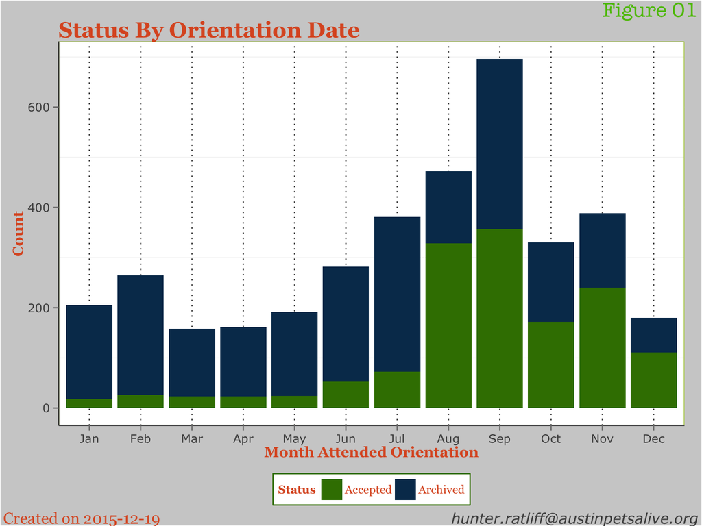

Status by Orientation Date (2014)

| Orientation | Accepted | Archived |
| --- | --- | --- |
| 2014-06-29 | 12 | 76 |
| 2014-07-12 | 9 | 86 |
| 2014-08-02 | 5 | 72 |
| 2014-08-24 | 5 | 68 |
| 2014-09-07 | 5 | 83 |
| 2014-09-14 | 6 | 62 |
| 2014-09-23 | 5 | 97 |
| 2014-09-27 | 10 | 87 |
| 2014-10-13 | 12 | 81 |
| 2014-10-25 | 8 | 76 |
| 2014-11-09 | 8 | 72 |
| 2014-11-22 | 13 | 74 |
| 2014-12-13 | 7 | 69 |

Status by Orientation Date (2015)

| Orientation | Accepted | Archived |
| --- | --- | --- |
| 2015-01-11 | 10 | 91 |
| 2015-01-25 | 8 | 96 |
| 2015-02-03 | 4 | 79 |
| 2015-02-14 | 15 | 80 |
| 2015-02-22 | 7 | 79 |
| 2015-03-15 | 10 | 60 |
| 2015-03-28 | 13 | 75 |
| 2015-04-11 | 10 | 77 |
| 2015-04-26 | 13 | 62 |
| 2015-05-09 | 11 | 84 |
| 2015-05-31 | 13 | 84 |
| 2015-06-13 | 16 | 81 |
| 2015-06-28 | 24 | 73 |
| 2015-07-08 | 11 | 35 |
| 2015-07-12 | 20 | 86 |
| 2015-07-22 | 5 | 11 |
| 2015-07-25 | 23 | 74 |
| 2015-07-30 | 4 | 17 |
| 2015-08-04 | 21 | NA |
| 2015-08-05 | 14 | NA |
| 2015-08-09 | 127 | 1 |
| 2015-08-19 | 18 | NA |
| 2015-08-20 | 44 | NA |
| 2015-08-29 | 94 | 3 |
| 2015-09-13 | 77 | 6 |
| 2015-09-16 | 21 | NA |
| 2015-09-19 | 83 | 2 |
| 2015-09-22 | 63 | NA |
| 2015-09-27 | 86 | 3 |
| 2015-10-14 | 29 | NA |
| 2015-10-17 | 82 | 1 |
| 2015-10-29 | 41 | NA |
| 2015-11-08 | 77 | 1 |
| 2015-11-12 | 25 | 1 |
| 2015-11-18 | 23 | NA |
| 2015-11-21 | 94 | NA |
| 2015-12-03 | 39 | NA |
| 2015-12-10 | 21 | NA |
| 2015-12-14 | 21 | NA |
| 2015-12-16 | 23 | NA |

## Number of Volunteers With Hours

Here’s a histogram showing the number of volunteers who went through orientation (`Figure 02A`). Each orientation date is further broken down by the fill-color, representing the number of volunteers who have `Hours > 0`.

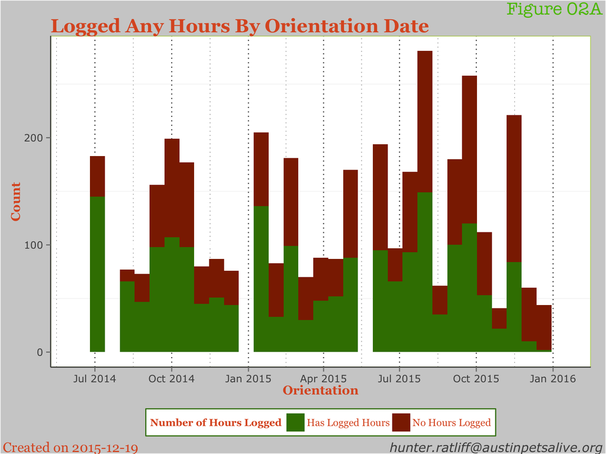

`Figure 02B` is the same graph as `Figure 02A`, only the y-axis has been changed to reflect the percentage who have logged any hours (as opposed to the count in the previous figure).

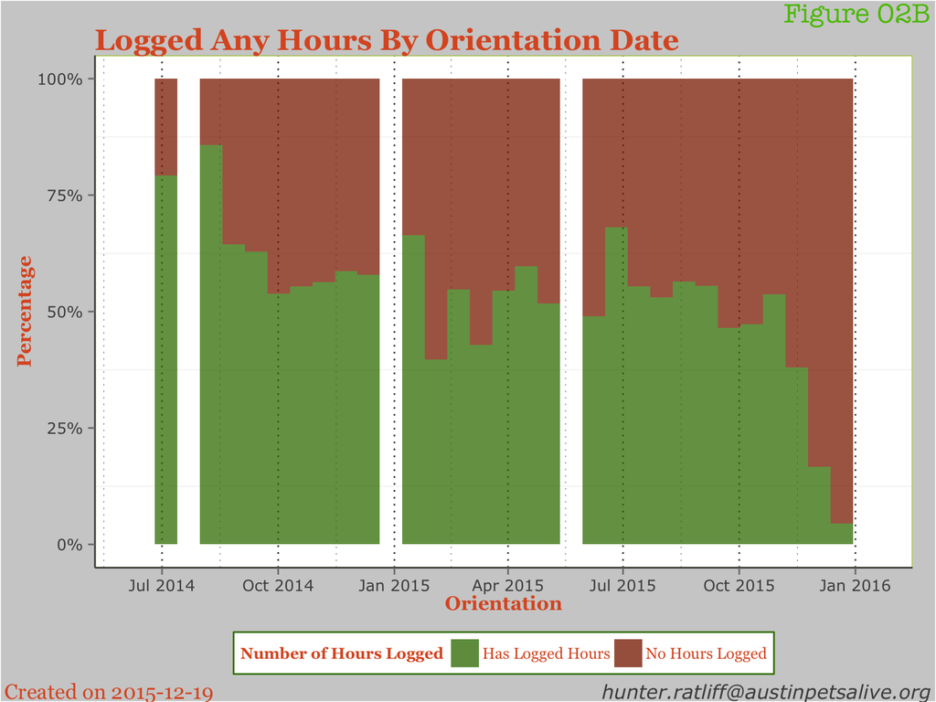

`Figure 03` is similar to the previous visualization reflecting the percentage of people who have logged any hours, but goes into a little more of a nuanced perspective. The graph is faceted by the year in which the orientation took place, and each bar represents an unique orientation (in the previous figures, dates were aggregated together into bins). Each bar is filled by a color representing the month, and the transpecrancy of each bar relfects the total number of volunteers who attended that orientation.

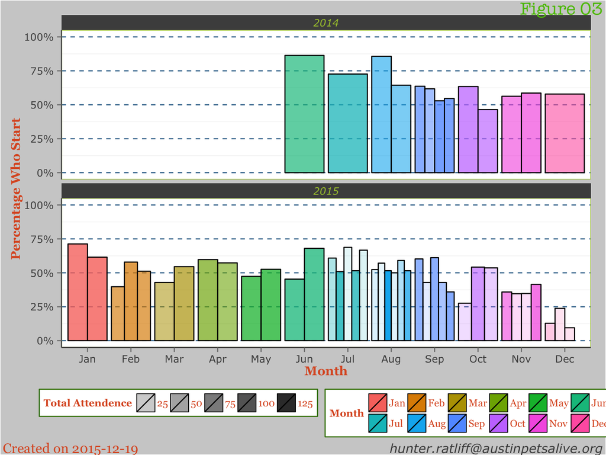

## Total Hours Logged

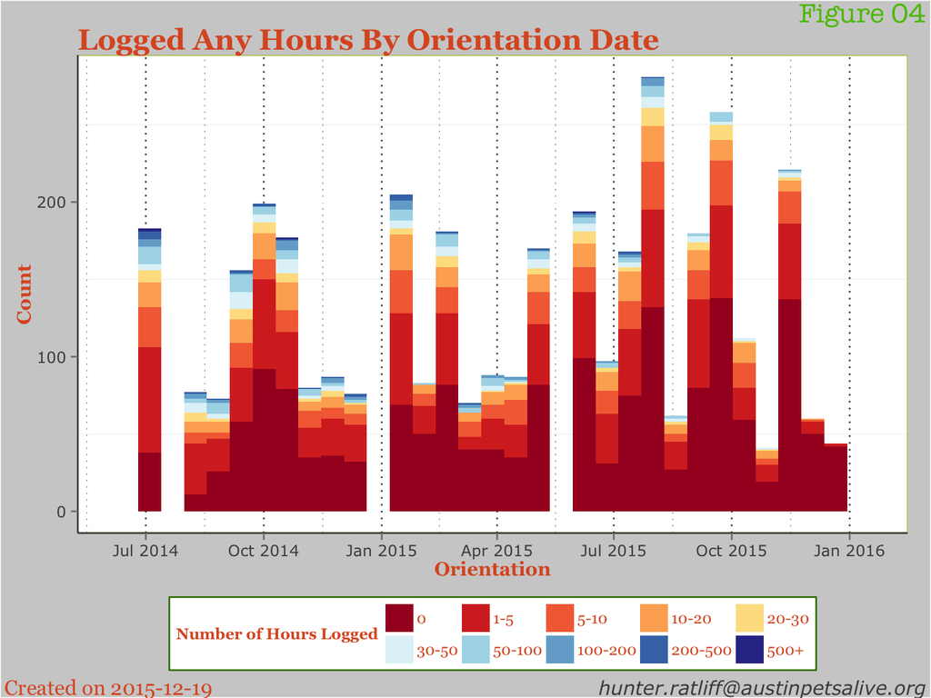

## Average Number of Hours Logged Per Volunteer

# Focusing on Volunteers From 2015 Only

```r
## Select hours that were logged in 2015 only
Hours.2015 <- Vol_Hours %>%
  filter(Date > ymd("2015-01-01"),
         Date < ymd("2015-12-18"))

## Select profiles with an orientation date in 2015 only
Profs.2015 <- Vol_Profs %>%
  select(User.ID, Status, Age=Q.Age, Hours.Total=Hours,
         Start=Orientation, End=Status.Date, Login=Date.Login) %>%
  filter(Start > ymd("2015-01-01"),
         Start < ymd("2015-12-18"))

# If a volunteer still has the 'Accepted' status, mark their end date
# as Dec 18th
Profs.2015$End[Profs.2015$Status=="Accepted"] <- ymd("2015-12-18")

## Join the Hours data frame with the profiles by User.ID using a left
## join, then filter out any hours that didn't come from volunteers
## who did their orientetion in 2015
df.2015 <- left_join(Hours.2015, Profs.2015, by = "User.ID") %>%
  filter(!is.na(Status)) %>%
  # make variable measuing days since  vols orientation
  mutate(SinceOrt = as.numeric(difftime(as.Date(Date),
                                        as.Date(Start),
                                        units = "days"))) %>%
  filter(SinceOrt>=0) %>% tbl_df()
```

Age Breakdown by Orientation

| Start | 11- | 12-15 | 16-17 | 18+ | Total |
| --- | --- | --- | --- | --- | --- |
| 2015-01-11 | 3 | 12 | 5 | 81 | 101 |
| 2015-01-25 | 3 | 12 | 3 | 86 | 104 |
| 2015-02-03 | NA | NA | NA | 83 | 83 |
| 2015-02-14 | 4 | 7 | 7 | 77 | 95 |
| 2015-02-22 | 1 | 8 | 3 | 74 | 86 |
| 2015-03-15 | NA | 6 | 4 | 60 | 70 |
| 2015-03-28 | 1 | 7 | 6 | 74 | 88 |
| 2015-04-11 | NA | 13 | 3 | 71 | 87 |
| 2015-04-26 | 3 | 6 | 4 | 62 | 75 |
| 2015-05-09 | 6 | 10 | 11 | 68 | 95 |
| 2015-05-31 | 5 | 17 | 9 | 66 | 97 |
| 2015-06-13 | NA | 19 | 7 | 71 | 97 |
| 2015-06-28 | 1 | 11 | 11 | 74 | 97 |
| 2015-07-08 | NA | 5 | 2 | 39 | 46 |
| 2015-07-12 | 2 | 17 | 8 | 79 | 106 |
| 2015-07-22 | 1 | NA | NA | 15 | 16 |
| 2015-07-25 | 1 | 12 | 10 | 74 | 97 |
| 2015-07-30 | NA | 1 | 1 | 19 | 21 |
| 2015-08-04 | 1 | 2 | 1 | 17 | 21 |
| 2015-08-05 | NA | 1 | 1 | 12 | 14 |
| 2015-08-09 | 3 | 16 | 7 | 102 | 128 |
| 2015-08-19 | NA | 3 | 2 | 13 | 18 |
| 2015-08-20 | NA | 5 | 3 | 36 | 44 |
| 2015-08-29 | 1 | 11 | 6 | 79 | 97 |
| 2015-09-13 | 2 | 8 | 6 | 67 | 83 |
| 2015-09-16 | NA | NA | NA | 21 | 21 |
| 2015-09-19 | NA | 11 | 5 | 69 | 85 |
| 2015-09-22 | NA | NA | NA | 63 | 63 |
| 2015-09-27 | 1 | 12 | 3 | 73 | 89 |
| 2015-10-14 | NA | NA | NA | 29 | 29 |
| 2015-10-17 | 1 | 6 | 6 | 70 | 83 |
| 2015-10-29 | 1 | 3 | 1 | 36 | 41 |
| 2015-11-08 | 2 | 6 | 4 | 66 | 78 |
| 2015-11-12 | 1 | 3 | NA | 22 | 26 |
| 2015-11-18 | 2 | 1 | NA | 20 | 23 |
| 2015-11-21 | 1 | 6 | 3 | 84 | 94 |
| 2015-12-03 | 1 | 1 | 5 | 32 | 39 |
| 2015-12-10 | NA | 1 | 1 | 19 | 21 |
| 2015-12-14 | NA | NA | NA | 21 | 21 |
| 2015-12-16 | NA | 1 | 1 | 21 | 23 |

Status Breakdown by Orientation

| Start | Accepted | Archived | Total |
| --- | --- | --- | --- |
| 2015-01-11 | 10 | 91 | 101 |
| 2015-01-25 | 8 | 96 | 104 |
| 2015-02-03 | 4 | 79 | 83 |
| 2015-02-14 | 15 | 80 | 95 |
| 2015-02-22 | 7 | 79 | 86 |
| 2015-03-15 | 10 | 60 | 70 |
| 2015-03-28 | 13 | 75 | 88 |
| 2015-04-11 | 10 | 77 | 87 |
| 2015-04-26 | 13 | 62 | 75 |
| 2015-05-09 | 11 | 84 | 95 |
| 2015-05-31 | 13 | 84 | 97 |
| 2015-06-13 | 16 | 81 | 97 |
| 2015-06-28 | 24 | 73 | 97 |
| 2015-07-08 | 11 | 35 | 46 |
| 2015-07-12 | 20 | 86 | 106 |
| 2015-07-22 | 5 | 11 | 16 |
| 2015-07-25 | 23 | 74 | 97 |
| 2015-07-30 | 4 | 17 | 21 |
| 2015-08-04 | 21 | NA | 21 |
| 2015-08-05 | 14 | NA | 14 |
| 2015-08-09 | 127 | 1 | 128 |
| 2015-08-19 | 18 | NA | 18 |
| 2015-08-20 | 44 | NA | 44 |
| 2015-08-29 | 94 | 3 | 97 |
| 2015-09-13 | 77 | 6 | 83 |
| 2015-09-16 | 21 | NA | 21 |
| 2015-09-19 | 83 | 2 | 85 |
| 2015-09-22 | 63 | NA | 63 |
| 2015-09-27 | 86 | 3 | 89 |
| 2015-10-14 | 29 | NA | 29 |
| 2015-10-17 | 82 | 1 | 83 |
| 2015-10-29 | 41 | NA | 41 |
| 2015-11-08 | 77 | 1 | 78 |
| 2015-11-12 | 25 | 1 | 26 |
| 2015-11-18 | 23 | NA | 23 |
| 2015-11-21 | 94 | NA | 94 |
| 2015-12-03 | 39 | NA | 39 |
| 2015-12-10 | 21 | NA | 21 |
| 2015-12-14 | 21 | NA | 21 |
| 2015-12-16 | 23 | NA | 23 |

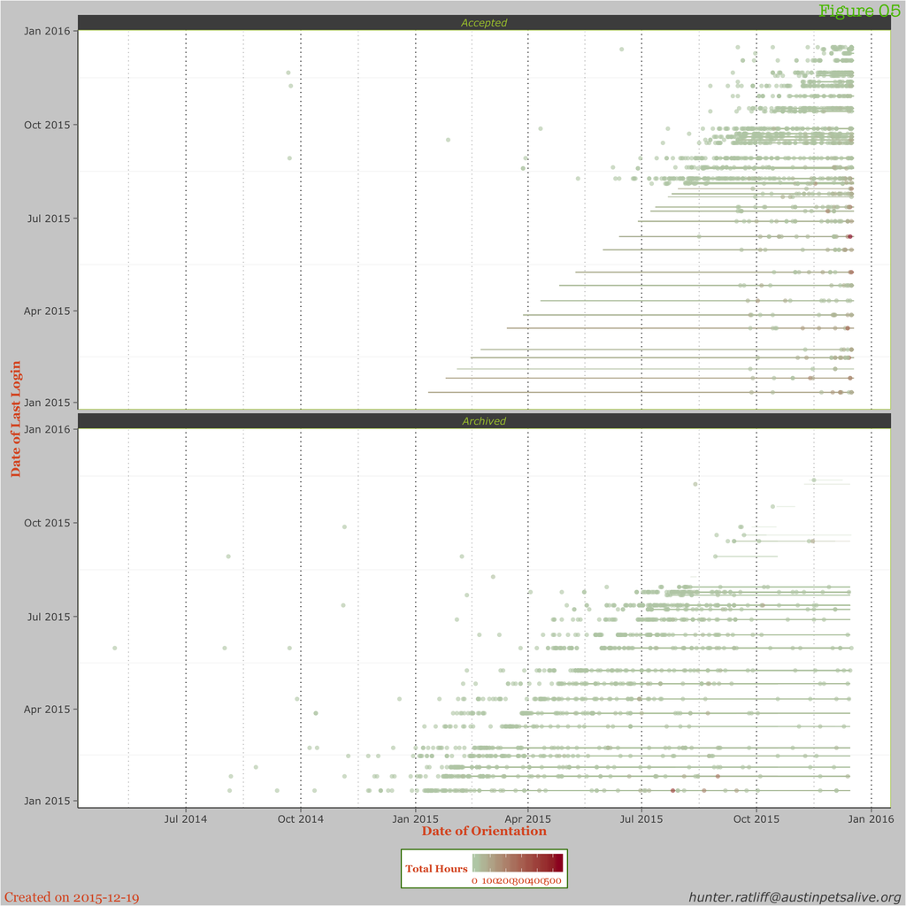

## What Does The First 90 Days Look Like?

### First Login

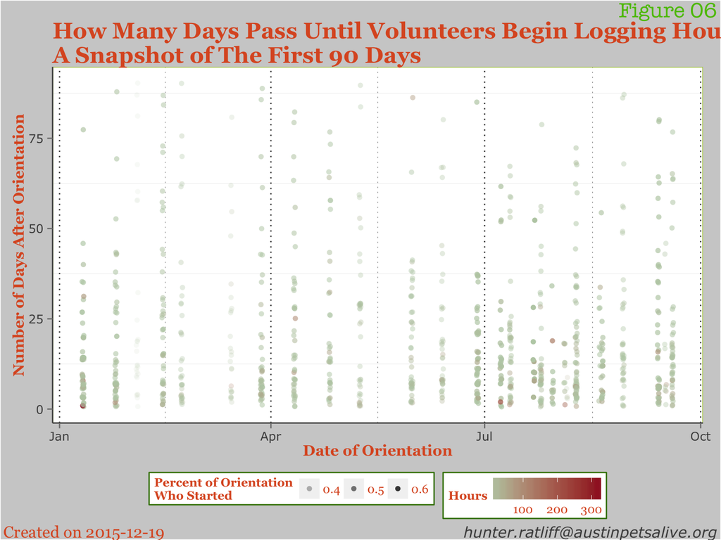

# (2) By Volunteer’s Length of Stay

### How Many Attend Orientation?

### How Many Log In Afterwards?

## How Many Volunteers Even Start?

#### Measurement: Number of Entries Logged

1. Threshold: 1 Entry
2. Threshold: 2 Entries
3. Threshold: 3 Entries
4. Threshold: 5 Entries
5. Threshold: 10 Entries
6. Threshold: 20 Entries

#### Measurement: Number of Hours Logged

1. Threshold: Any amount of time
2. Threshold: 2 Hours
3. Threshold: 5 Hours
4. Threshold: 10 Hours
5. Threshold: 20 Hours
6. Threshold: 50 Hours

### Bonus: How Long Did It Take Them To Get Engaged?

## Of Those Who Start, How Long Are They Engaged?

### How Much Time Passes Between Each Logged Event?

### How Long Until Most Volunteers Stop Volunteering?

#### What’s The Shape Of This Curve?

#### Has This Curve Changed Over Time?

### Bonus: What Does This Mean In Terms Of Income/Expenses?

# (3) Types of Volunteers

## Based On Interests

## Based On Age

## Based On Sex

## Based On Employeer

## Types According to *Strategic Volunteer Engagement*

[Strategic Volunteer Engagement](http://www.volunteeralive.org/docs/Strategic%20Volunteer%20Engagement.pdf)

### Time For Service: *Eposodic vs Long Term*

### Connection To Service: *Affiliation vs Skill Focus*

## Consistancy of Volunteer

## Does The Volunteer Volunteer On Other Teams Too?

# (4) Net Flow

## How Does The Flow Of Volunteers Look Within Each Program?

### Number of Volunteer Over Time

### Number of Hours Logged Over Time

### Influx of Volunteers In/Out From The Team

# Contact

**Hunter Ratliff**

Email: hunterratliff1@gmail.com  
Twitter: @HunterRatliff1  
Github: [HunterRatliff1](https://github.com/hunterratliff1)  
RPubs: HunterRatliff1

**Austin Pets Alive Contact Info**

Adopt | Donate | Foster | Volunteer

MY EMAIL: Out of respect for the time of our staff/volunteers, please direct all data requests and more technical inquires to my email!

```
Copyright (C) 2015 Austin Pets Alive, Hunter Ratliff

This program is free software: you can redistribute it and/or modify
it under the terms of the GNU General Public License as published by
the Free Software Foundation, either version 3 of the License, or
(at your option) any later version.

This program is distributed in the hope that it will be useful,
but WITHOUT ANY WARRANTY; without even the implied warranty of
MERCHANTABILITY or FITNESS FOR A PARTICULAR PURPOSE.  See the
GNU General Public License for more details.

You should have received a copy of the GNU General Public License
along with this program.  If not, see <http://www.gnu.org/licenses/>.
```

```r
devtools::session_info()
##  setting  value
##  version  R version 3.2.3 (2015-12-10)
##  system   x86_64, darwin13.4.0
##  ui       X11
##  language (EN)
##  collate  en_US.UTF-8
##  tz       America/Chicago
##  date     2015-12-19
##
##  package      * version date       source
##  assertthat     0.1     2013-12-06 CRAN (R 3.2.0)
##  cellranger     1.0.0   2015-06-20 CRAN (R 3.2.0)
##  colorspace     1.2-6   2015-03-11 CRAN (R 3.2.0)
##  curl           0.9.4   2015-11-20 CRAN (R 3.2.2)
##  DBI            0.3.1   2014-09-24 CRAN (R 3.2.0)
##  devtools     * 1.9.1   2015-09-11 CRAN (R 3.2.0)
##  digest         0.6.8   2014-12-31 CRAN (R 3.2.0)
##  dplyr        * 0.4.3   2015-09-01 CRAN (R 3.2.0)
##  evaluate       0.8     2015-09-18 CRAN (R 3.2.0)
##  formatR        1.2.1   2015-09-18 CRAN (R 3.2.0)
##  ggplot2      * 1.0.1   2015-03-17 CRAN (R 3.2.0)
##  ggthemes     * 2.2.1   2015-07-01 CRAN (R 3.2.0)
##  googlesheets * 0.1.0   2015-07-05 CRAN (R 3.2.0)
##  gridExtra    * 2.0.0   2015-07-14 CRAN (R 3.2.0)
##  gtable         0.1.2   2012-12-05 CRAN (R 3.2.0)
##  highr          0.5.1   2015-09-18 CRAN (R 3.2.0)
##  htmltools      0.2.6   2014-09-08 CRAN (R 3.2.0)
##  httr           1.0.0   2015-06-25 CRAN (R 3.2.0)
##  jsonlite       0.9.19  2015-11-28 CRAN (R 3.2.2)
##  knitr        * 1.11    2015-08-14 CRAN (R 3.2.1)
##  labeling       0.3     2014-08-23 CRAN (R 3.2.0)
##  lazyeval       0.1.10  2015-01-02 CRAN (R 3.2.0)
##  lubridate    * 1.3.3   2013-12-31 CRAN (R 3.2.0)
##  magrittr       1.5     2014-11-22 CRAN (R 3.2.0)
##  MASS           7.3-45  2015-11-10 CRAN (R 3.2.3)
##  memoise        0.2.1   2014-04-22 CRAN (R 3.2.0)
##  munsell        0.4.2   2013-07-11 CRAN (R 3.2.0)
##  plyr           1.8.3   2015-06-12 CRAN (R 3.2.0)
##  proto          0.3-10  2012-12-22 CRAN (R 3.2.0)
##  R6             2.1.1   2015-08-19 CRAN (R 3.2.0)
##  RColorBrewer * 1.1-2   2014-12-07 CRAN (R 3.2.0)
##  Rcpp           0.12.2  2015-11-15 CRAN (R 3.2.2)
##  reshape2     * 1.4.1   2014-12-06 CRAN (R 3.2.0)
##  rmarkdown      0.8.2   2015-11-20 Github (rstudio/rmarkdown@0d2cd06)
##  scales       * 0.3.0   2015-08-25 CRAN (R 3.2.0)
##  stringi      * 1.0-1   2015-10-22 CRAN (R 3.2.0)
##  stringr        1.0.0   2015-04-30 CRAN (R 3.2.0)
##  tidyr        * 0.3.1   2015-09-10 CRAN (R 3.2.0)
##  xml2           0.1.2   2015-09-01 CRAN (R 3.2.0)
##  xtable       * 1.8-0   2015-11-02 CRAN (R 3.2.1)
##  yaml           2.1.13  2014-06-12 CRAN (R 3.2.0)
```